# MIS 306 Data Analysis | Homework 2

# Statistical Tests

## Kolmogorov-Smirnov Test

```r
# Compare Mondays and Tuesdays..
ks.test(ba.ret[wday(index(ba.ret))==2], ba.ret[wday(index(ba.ret))==3])
```

```
##
##  Asymptotic two-sample Kolmogorov-Smirnov test
##
## data:  ba.ret[wday(index(ba.ret)) == 2] and ba.ret[wday(index(ba.ret)) == 3]
## D = 0.063855, p-value = 0.05105
## alternative hypothesis: two-sided
```

The test statistic (`D = 0.063855`) represents the maximum difference between the two cumulative distributions. The p-value of (`0.05105`) is close to (`0.05`), suggesting that there is weak evidence against the null hypothesis, but it does not reach conventional significance levels. Therefore, the difference in return distributions between these two days is not statistically significant at the 5% level, although it is marginal.

```r
# Compare Mondays and Fridays..
ks.test(ba.ret[wday(index(ba.ret))==2], ba.ret[wday(index(ba.ret))==6])
```

```
##
##  Asymptotic two-sample Kolmogorov-Smirnov test
##
## data:  ba.ret[wday(index(ba.ret)) == 2] and ba.ret[wday(index(ba.ret)) == 6]
## D = 0.049352, p-value = 0.2286
## alternative hypothesis: two-sided
```

```r
# Let's obtain all.. Create 5*5 matrix.. We use only upper-triangle
# See the structure of ks.test result first..
p.matr <- matrix(rep(0, 5*5), nrow=5)
colnames(p.matr) <- rownames(p.matr) <- levels(wday(index(ba.ret), label=T))[2:6]

for (i in 2:6){
  for (j in i:6){
    p.matr[i-1,j-1] <- ks.test(as.numeric(ba.ret[wday(index(ba.ret))==i]), as.numeric(ba.ret[wday(index(ba.ret))==j]))$p.value
  }
}

# p-vales matrix of  Kolmogorov-Smirnov Tests
round(p.matr, 3)
```

```
##     Pzt   Sal   Çar   Per   Cum
## Pzt   1 0.997 0.701 0.057 0.881
## Sal   0 1.000 0.841 0.107 0.717
## Çar   0 0.000 1.000 0.085 0.669
## Per   0 0.000 0.000 1.000 0.075
## Cum   0 0.000 0.000 0.000 1.000
```

```r
# Let's obtain all months returns.. Create 12*12 matrix.. We use only upper-triangle
# See the structure of ks.test result first..
pm.matr <- matrix(rep(0, 12*12), nrow=12)
colnames(pm.matr) <- rownames(pm.matr) <- levels(month(index(ba.mret), label=T))

for (i in 1:12){
  for (j in i:12){
    pm.matr[i,j] <- ks.test(as.numeric(ba.mret[month(index(ba.mret))==i]), as.numeric(ba.mret[month(index(ba.mret))==j]))$p.value
  }
}

# p-vales matrix of  Kolmogorov-Smirnov Tests
round(pm.matr, 3)
```

```
##     Oca   Şub   Mar   Nis   May   Haz   Tem   Ağu   Eyl   Eki   Kas   Ara
## Oca   1 0.623 0.966 0.893 0.781 0.781 0.972 0.503 0.781 0.972 0.503 0.503
## Şub   0 1.000 0.808 0.978 0.623 0.587 0.882 0.181 0.870 0.338 0.087 0.960
## Mar   0 0.000 1.000 0.978 0.924 0.703 0.792 0.825 0.808 0.999 0.159 0.273
## Nis   0 0.000 0.000 1.000 0.924 0.935 0.935 0.509 0.893 0.792 0.338 0.758
## May   0 0.000 0.000 0.000 1.000 0.781 0.972 0.503 0.781 0.781 0.503 0.781
## Haz   0 0.000 0.000 0.000 0.000 1.000 0.781 0.781 0.781 0.781 0.132 0.503
## Tem   0 0.000 0.000 0.000 0.000 0.000 1.000 0.275 0.781 0.781 0.781 0.972
## Ağu   0 0.000 0.000 0.000 0.000 0.000 0.000 1.000 0.503 0.972 0.132 0.132
## Eyl   0 0.000 0.000 0.000 0.000 0.000 0.000 0.000 1.000 0.972 0.503 0.781
## Eki   0 0.000 0.000 0.000 0.000 0.000 0.000 0.000 0.000 1.000 0.275 0.275
## Kas   0 0.000 0.000 0.000 0.000 0.000 0.000 0.000 0.000 0.000 1.000 0.275
## Ara   0 0.000 0.000 0.000 0.000 0.000 0.000 0.000 0.000 0.000 0.000 1.000
```

## Time Series Decomposition

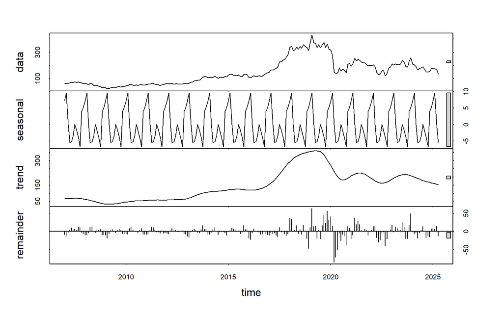

```r
ba.monthly.adj <- Ad(to.monthly(BA))

ba.ts <- ts(as.numeric(ba.monthly.adj), start = c(2007, 1), frequency = 12)

ba.stl <- stl(ba.ts, s.window = "periodic")

plot(ba.stl)
```

The graph presents a time series decomposition, breaking the data into four components: observed data, seasonal pattern, trend, and remainder (residuals). The seasonal component shows a repeating pattern, indicating periodic fluctuations. The trend captures long-term movements, with a steady rise until 2019, followed by a decline. The remainder represents irregular variations, with noticeable spikes around 2020. This analysis helps identify underlying patterns and anomalies in the data.

## Forecasting

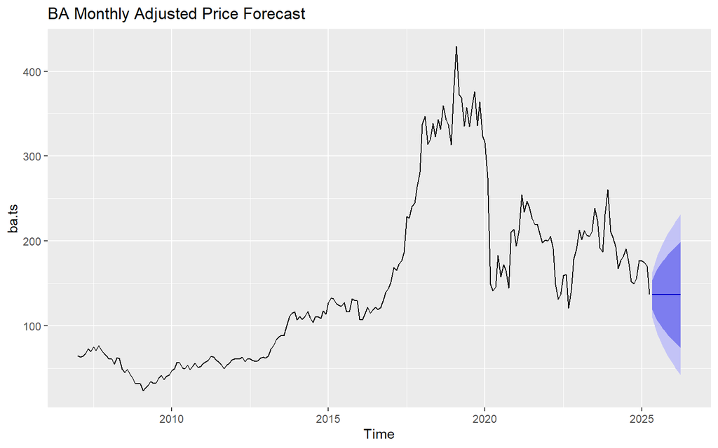

```r
library(forecast)
library(ggplot2)

ba.ets <- ets(ba.ts)
autoplot(forecast(ba.ets, h = 12)) +
  ggtitle("BA Monthly Adjusted Price Forecast")
```

```r
summary(ba.ets)
```

```
## ETS(M,N,N)
##
## Call:
## ets(y = ba.ts)
##
##   Smoothing parameters:
##     alpha = 0.9999
##
##   Initial states:
##     l = 64.0674
##
##   sigma:  0.0998
##
##      AIC     AICc      BIC
## 2275.021 2275.132 2285.202
##
## Training set error measures:
##                     ME     RMSE      MAE        MPE     MAPE    MASE       ACF1
## Training set 0.3296968 18.75692 11.27326 -0.1939746 7.426847 0.25001 0.02766114
```

The graph shows Boeing’s monthly adjusted stock price with a forecast for the near future. The stock saw steady growth until 2019, followed by a sharp decline in 2020 and fluctuating recovery afterward. The blue-shaded forecast area indicates possible price movements, with uncertainty increasing over time. The stock’s future trend remains uncertain, depending on market and economic conditions.

# Smoothing

## Adjusted Close

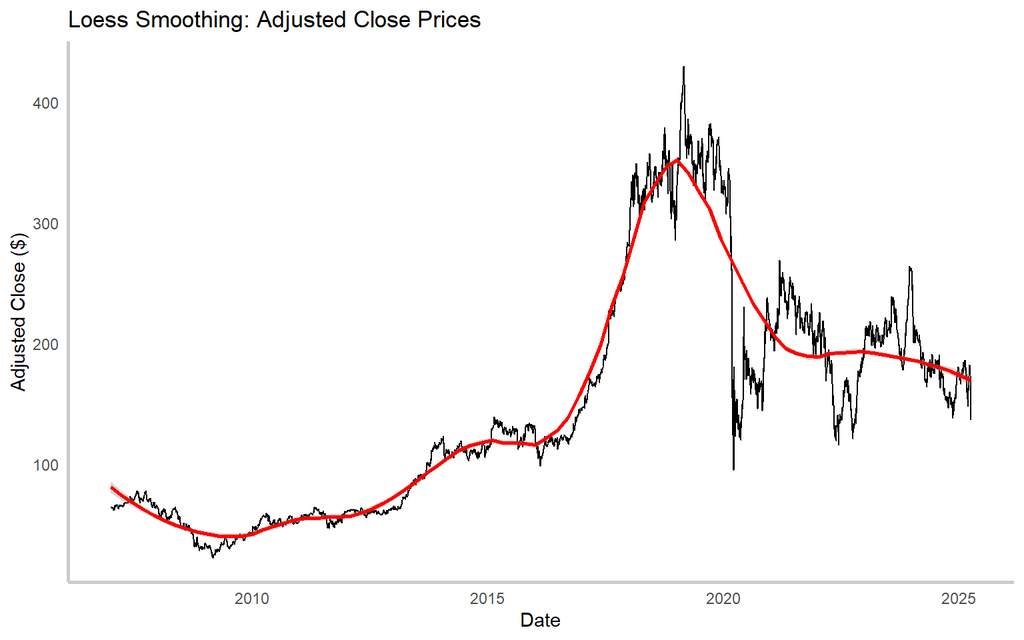

```r
library(zoo)
library(fpp3)
library(mgcv)

autoplot(ba) +
  geom_smooth(method = "loess", span = 0.3, color = "red") +
  labs(
    title = "Loess Smoothing: Adjusted Close Prices",
    x = "Date",
    y = "Adjusted Close ($)"
  ) +
  theme_minimal() +
  theme(
    panel.grid = element_blank(),
    axis.line = element_line(linewidth = 1, colour = "grey80"))
```

## Volume

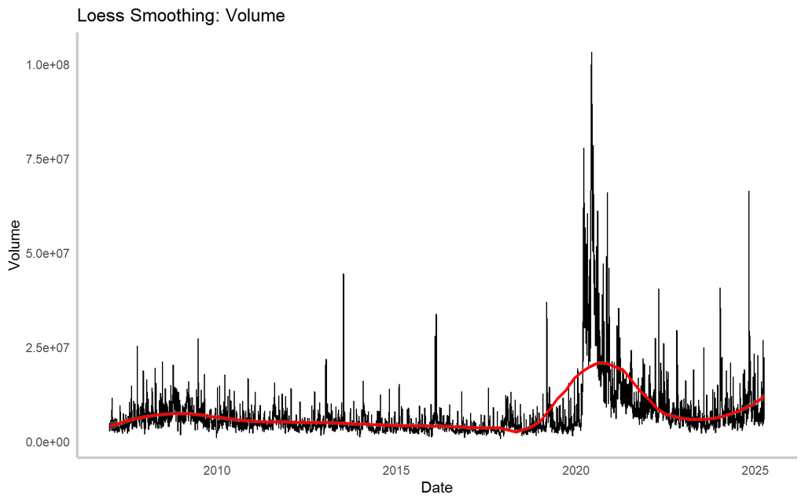

```r
autoplot(BA$BA.Volume) +
  geom_smooth(method = "loess", span = 0.3, color = "red") +
  labs(
    title = "Loess Smoothing: Volume",
    x = "Date",
    y = "Volume"
  ) +
  theme_minimal() +
  theme(
    panel.grid = element_blank(),
    axis.line = element_line(linewidth = 1, colour = "grey80"))
```

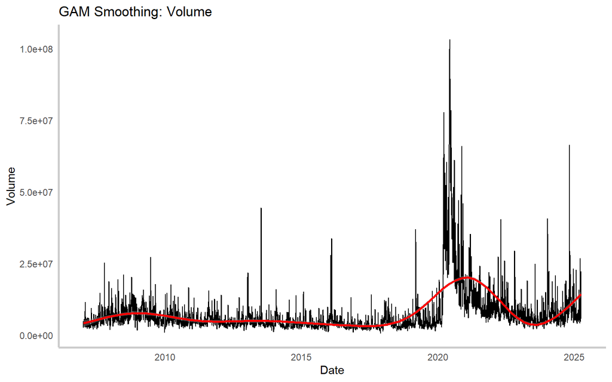

```r
autoplot(BA$BA.Volume) +
  geom_smooth(method = "gam", formula = y ~ s(x, bs = "cs"), color = "red") +
  labs(
    title = "GAM Smoothing: Volume",
    x = "Date",
    y = "Volume"
  ) +
  theme_minimal() +
  theme(
    panel.grid = element_blank(),
    axis.line = element_line(linewidth = 1, colour = "grey80"))
```

When we look at both `LOESS` and `GAM` smoothing plots, we can see that the `LOESS` captures more details and fluctuations in the data, while `GAM` produces a slightly smoother trend.

## High Prices

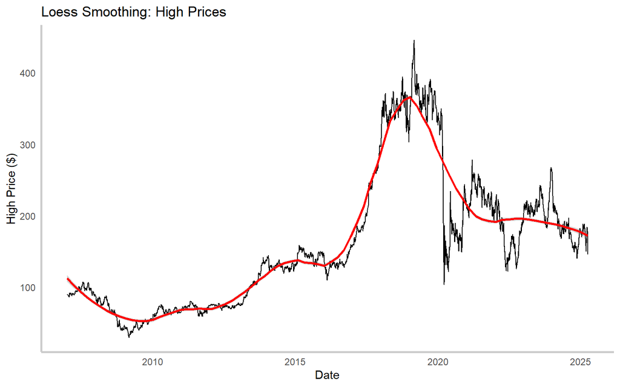

```r
autoplot(BA$BA.High) +
  geom_smooth(method = "loess", span = 0.3, color = "red") +
  labs(
    title = "Loess Smoothing: High Prices",
    x = "Date",
    y = "High Price ($)"
  ) +
  theme_minimal() +
  theme(
    panel.grid = element_blank(),
    axis.line = element_line(linewidth = 1, colour = "grey80"))
```

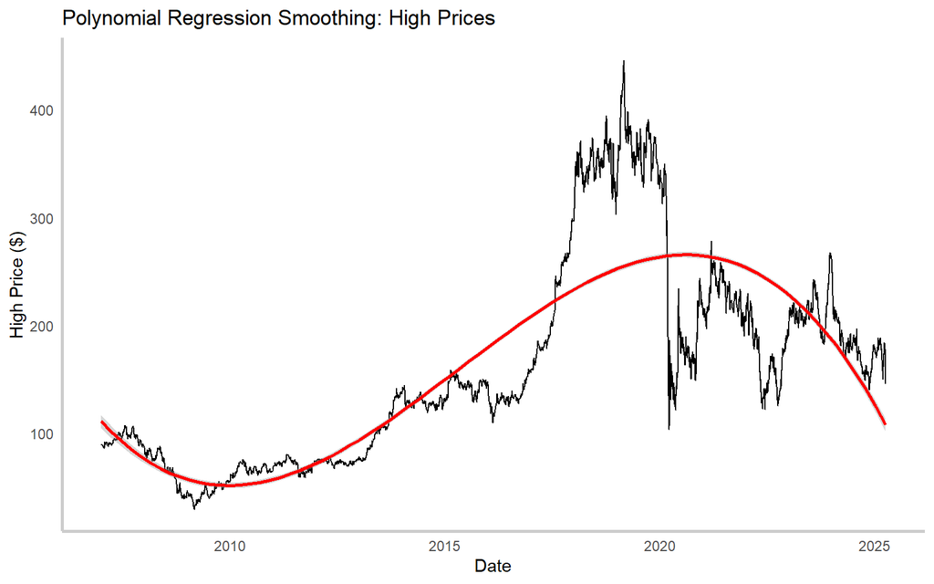

```r
autoplot(BA$BA.High) +
  geom_smooth(method = "lm", formula = y ~ poly(x, 3), color = "red") +
  labs(
    title = "Polynomial Regression Smoothing: High Prices",
    x = "Date",
    y = "High Price ($)"
  ) +
  theme_minimal() +
  theme(
    panel.grid = element_blank(),
    axis.line = element_line(linewidth = 1, colour = "grey80"))
```

When we look at both `LOESS` and `Polynomial Regression` smoothing plots, we can see that the `LOESS` captures more details and fluctuations in the data, while `Polynomial Regression` produces a smoother trend.

## Low Prices

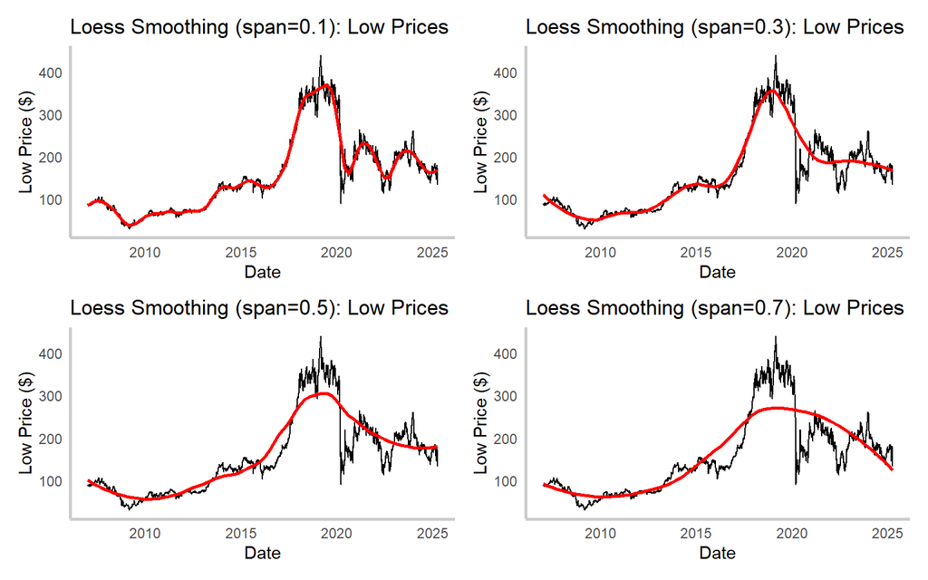

```r
library(patchwork)

plot1 <- autoplot(BA$BA.Low) +
  geom_smooth(method = "loess", span = 0.1, color = "red") +
  labs(
    title = "Loess Smoothing (span=0.1): Low Prices",
    x = "Date",
    y = "Low Price ($)"
  ) +
  theme_minimal() +
  theme(
    panel.grid = element_blank(),
    axis.line = element_line(linewidth = 1, colour = "grey80"))

plot2 <- autoplot(BA$BA.Low) +
  geom_smooth(method = "loess", span = 0.3, color = "red") +
  labs(
    title = "Loess Smoothing (span=0.3): Low Prices",
    x = "Date",
    y = "Low Price ($)"
  ) +
  theme_minimal() +
  theme(
    panel.grid = element_blank(),
    axis.line = element_line(linewidth = 1, colour = "grey80"))

plot3 <- autoplot(BA$BA.Low) +
  geom_smooth(method = "loess", span = 0.5, color = "red") +
  labs(
    title = "Loess Smoothing (span=0.5): Low Prices",
    x = "Date",
    y = "Low Price ($)"
  ) +
  theme_minimal() +
  theme(
    panel.grid = element_blank(),
    axis.line = element_line(linewidth = 1, colour = "grey80"))

plot4 <- autoplot(BA$BA.Low) +
  geom_smooth(method = "loess", span = 0.7, color = "red") +
  labs(
    title = "Loess Smoothing (span=0.7): Low Prices",
    x = "Date",
    y = "Low Price ($)"
  ) +
  theme_minimal() +
  theme(
    panel.grid = element_blank(),
    axis.line = element_line(linewidth = 1, colour = "grey80"))

(plot1 + plot2) / (plot3 + plot4)
```

The black lines show the actual low prices, while the red lines represent smoothed data. The graphs demonstrate how different spans of Loess smoothing affect the interpretation of trends. A smaller span, like (`0.1`), captures more details and fluctuations in the data, while a larger span, such as (`0.7`), produces a smoother trend, making it easier to observe the general direction of prices over time.

# Conclusion

The analysis of Boeing Company (`BA`) stock data from 2007 to 2025 has revealed important trends and patterns in return distributions across different timeframes. Weekly return comparisons demonstrated notable variations, particularly with Thursday showing higher average returns, while Friday exhibited lower performance, suggesting potential weekday effects on market behavior. `Kolmogorov-Smirnov` tests indicated weak or non-significant differences between return distributions for specific days, reinforcing the idea that while some patterns exist, they may not be statistically strong.

**Note:** Some of the interpretations and explanations were refined with the help of GPT.